# Persistent network model diagnostics - debugging fit issues

This file shows diagnostics for an edges-only persistent network model. In this file, we test whether fit issues are due to edapprox.

## Load packages and model fits

## 1. Edges only

This model has edges only and no constraints based on role class or to cap degree at 2. It also does not incorporate mortality into the disssolution coefficient. It uses the target statistic for edges and duration from our data, and it sets `edapprox=TRUE`. With this model, I got the error message about degeneracy with `init.method="zeros"` (“Number of edges in a simulated network exceeds that in the observed by a factor of more than 20”), so I set `init.method` to the NULL argument. Also note that in this model, our control settings did not adjust the MCMC intervals or burnin.

```r
nw <- network.initialize(10000,directed=FALSE)
time.step <- 7
fit.p1 <- netest(nw,
                formation = ~edges,
                target.stats = 2017.5,
                coef.diss = dissolution_coefs(dissolution = ~offset(edges), duration = 221 / time.step),
                edapprox = TRUE,
                set.control.ergm = control.ergm(MPLE.max.dyad.types = 1e9,
                                                 MCMLE.maxit = 250))
```

### MCMC diagnostics

```r
mcmc.diagnostics(fit.p1$fit)
```

```
## Sample statistics summary:
##
## Iterations = 16384:4209664
## Thinning interval = 1024
## Number of chains = 1
## Sample size per chain = 4096
##
## 1. Empirical mean and standard deviation for each variable,
##    plus standard error of the mean:
##
##           Mean             SD       Naive SE Time-series SE
##         3.0334        46.2117         0.7221         2.1102
##
## 2. Quantiles for each variable:
##
##   2.5%    25%    50%    75%  97.5%
## -86.50 -29.50   3.50  33.75  93.50
##
##
## Sample statistics cross-correlations:
##       edges
## edges     1
##
## Sample statistics auto-correlation:
## Chain 1
##              edges
## Lag 0    1.0000000
## Lag 1024 0.7903247
## Lag 2048 0.6192741
## Lag 3072 0.4895125
## Lag 4096 0.3769784
## Lag 5120 0.2936113
##
## Sample statistics burn-in diagnostic (Geweke):
## Chain 1
##
## Fraction in 1st window = 0.1
## Fraction in 2nd window = 0.5
##
##  edges
## 0.2015
##
## Individual P-values (lower = worse):
##     edges
## 0.8403198
## Joint P-value (lower = worse):  0.8209399 .
```

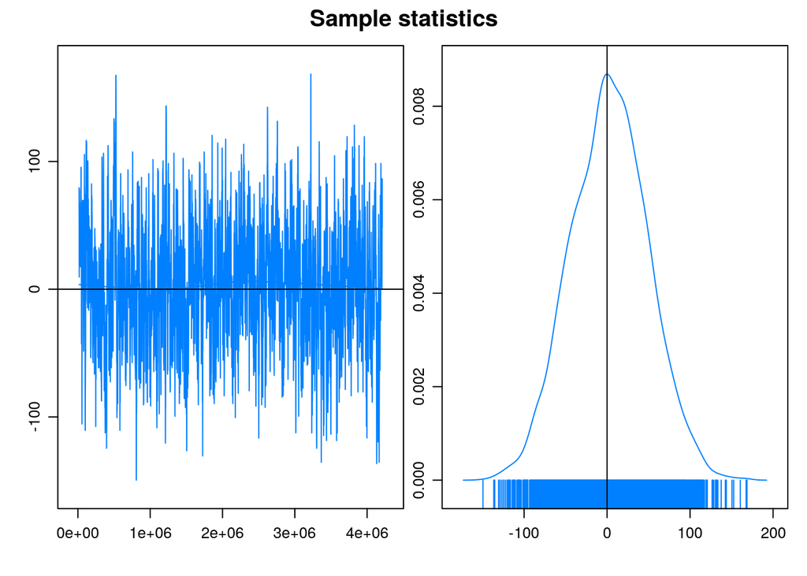

[output not shown]

### Summary of model fit

```r
summary(fit.p1)
```

```
##
## ==========================
## Summary of model fit
## ==========================
##
## Formula:   nw ~ edges
## <environment: 0x5577e76d1978>
##
## Iterations:  2 out of 250
##
## Monte Carlo MLE Results:
##        Estimate Std. Error MCMC % p-value
## edges -10.11825    0.02166      0  <1e-04 ***
## ---
## Signif. codes:  0 '***' 0.001 '**' 0.01 '*' 0.05 '.' 0.1 ' ' 1
##
## Log-likelihood was not estimated for this fit.
## To get deviances, AIC, and/or BIC from fit `object$fit` run
##   > object$fit<-logLik(object$fit, add=TRUE)
## to add it to the object or rerun this function with eval.loglik=TRUE.
##
## Dissolution Coefficients
## =======================
## Dissolution Model: ~offset(edges)
## Target Statistics: 31.57143
## Crude Coefficient: 3.420066
## Mortality/Exit Rate: 0
## Adjusted Coefficient: 3.420066
```

### Network diagnostics - MCMC burnin set to 1e+6 and using set.control.ergm

```r
(dx_pers1 <- netdx(fit.p1, nsims = 10, nsteps = 1000, ncores = 4, set.control.stergm = control.simulate.network(MCMC.burnin.min = 1e+6, MCMC.burnin.max = 1e+6), set.control.ergm = control.simulate.ergm(MCMC.interval = 1e+5, MCMC.burnin = 1e+6)))
```

```
##
## Network Diagnostics
## -----------------------
## - Simulating 10 networks
## - Calculating formation statistics
## - Calculating duration statistics
## - Calculating dissolution statistics
##
```

```
## EpiModel Network Diagnostics
## =======================
## Diagnostic Method: Dynamic
## Simulations: 10
## Time Steps per Sim: 1000
##
## Formation Diagnostics
## -----------------------
##       Target Sim Mean Pct Diff Sim SD
## edges 2017.5 2089.438    0.036 47.162
##
## Dissolution Diagnostics
## -----------------------
##                Target Sim Mean Pct Diff Sim SD
## Edge Duration  31.571   30.650   -0.029 30.082
## Pct Edges Diss  0.032    0.032   -0.002  0.004
```

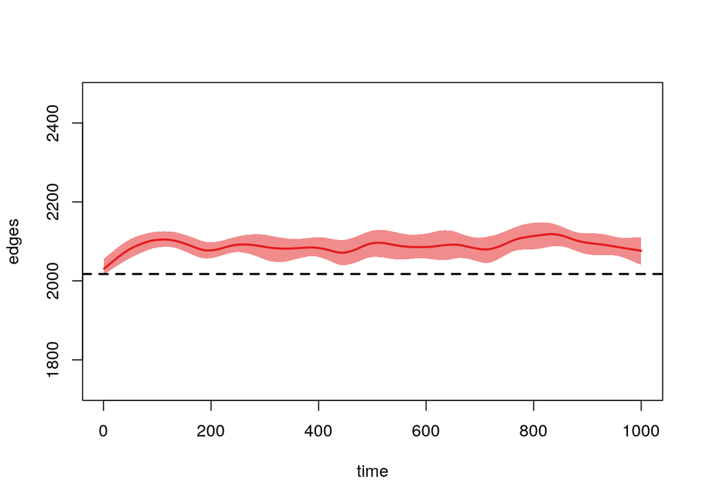

```r
plot(dx_pers1, type="formation")
```

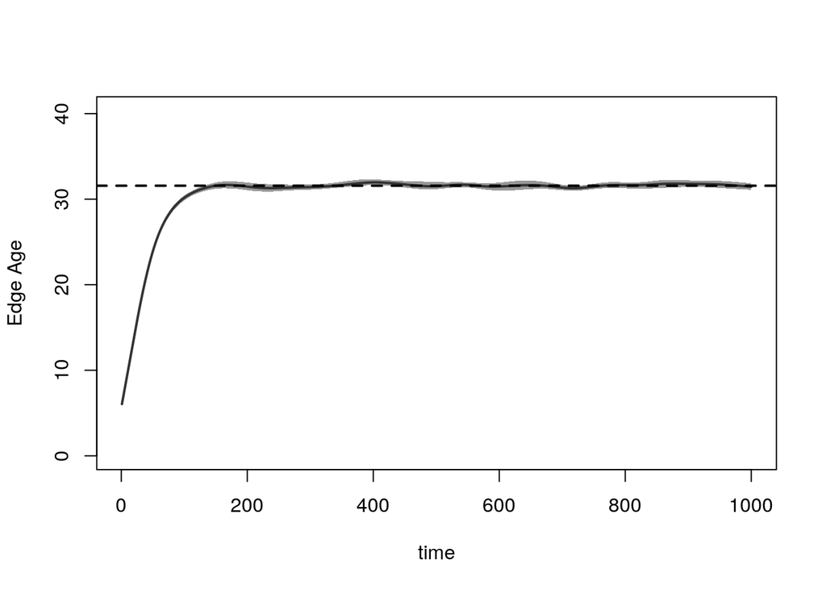

```r
plot(dx_pers1, type="duration")
```

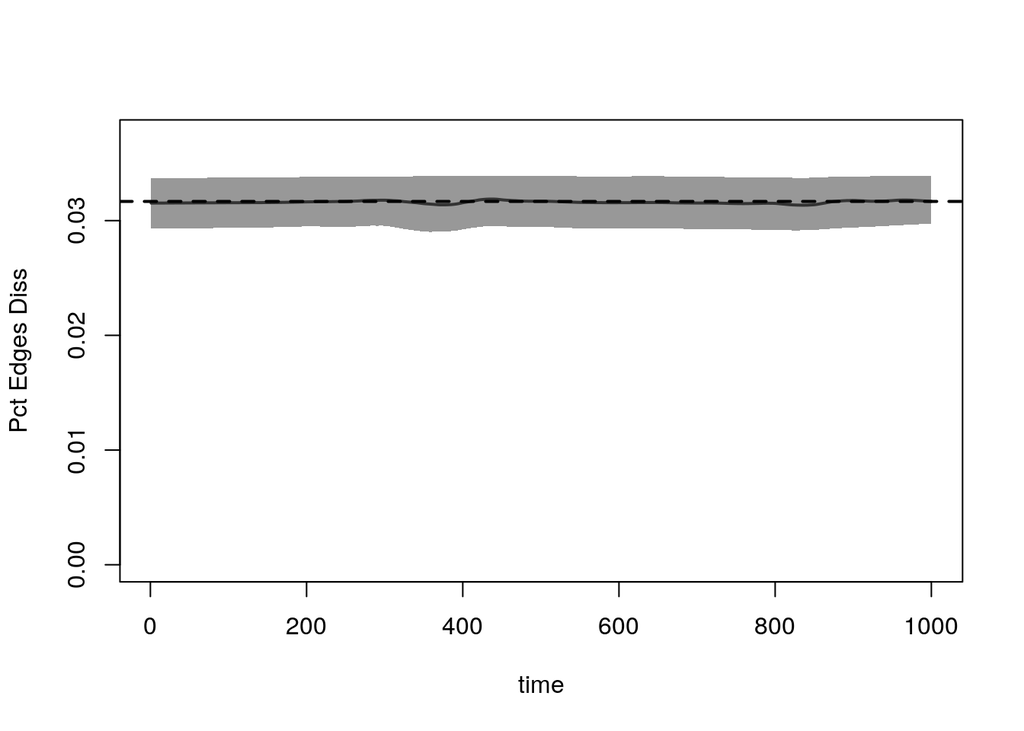

```r
plot(dx_pers1, type="dissolution")
```

## 2. Edges only but duration = 100 time steps

This model is the same as above but with duration set to 100 time steps

```r
nw <- network.initialize(10000,directed=FALSE)
time.step <- 7
fit.p2 <- netest(nw,
                formation = ~edges,
                target.stats = 2017.5,
                coef.diss = dissolution_coefs(dissolution = ~offset(edges), duration = 100),
                edapprox = TRUE,
                set.control.ergm = control.ergm(MPLE.max.dyad.types = 1e9,
                                                 MCMLE.maxit = 250))
```

### MCMC diagnostics

```r
mcmc.diagnostics(fit.p2$fit)
```

```
## Sample statistics summary:
##
## Iterations = 16384:4209664
## Thinning interval = 1024
## Number of chains = 1
## Sample size per chain = 4096
##
## 1. Empirical mean and standard deviation for each variable,
##    plus standard error of the mean:
##
##           Mean             SD       Naive SE Time-series SE
##        -4.3606        43.8015         0.6844         1.8208
##
## 2. Quantiles for each variable:
##
##  2.5%   25%   50%   75% 97.5%
## -89.5 -34.5  -4.5  25.5  80.5
##
##
## Sample statistics cross-correlations:
##       edges
## edges     1
##
## Sample statistics auto-correlation:
## Chain 1
##              edges
## Lag 0    1.0000000
## Lag 1024 0.7681400
## Lag 2048 0.5854385
## Lag 3072 0.4332209
## Lag 4096 0.3073340
## Lag 5120 0.2306956
##
## Sample statistics burn-in diagnostic (Geweke):
## Chain 1
##
## Fraction in 1st window = 0.1
## Fraction in 2nd window = 0.5
##
## edges
## 0.219
##
## Individual P-values (lower = worse):
##     edges
## 0.8266509
## Joint P-value (lower = worse):  0.8162693 .
```

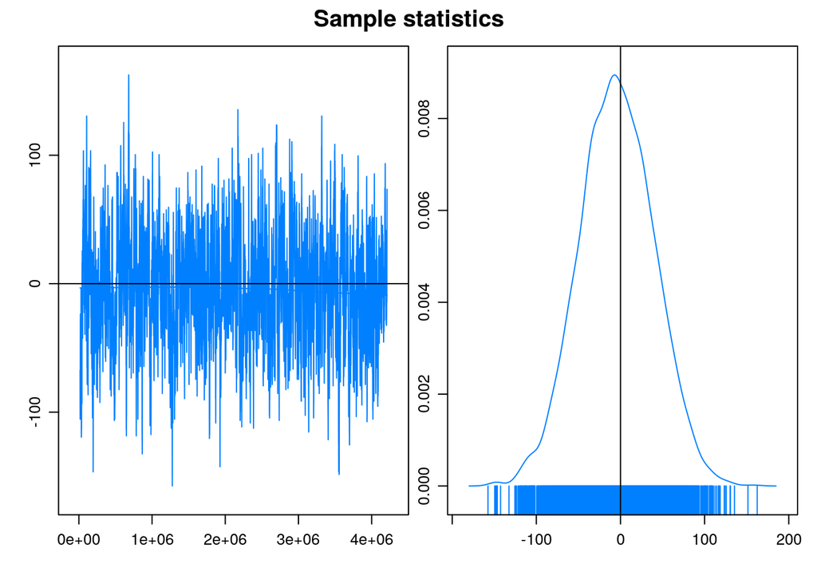

[output not shown]

### Summary of model fit

```r
summary(fit.p2)
```

```
##
## ==========================
## Summary of model fit
## ==========================
##
## Formula:   nw ~ edges
## <environment: 0x5577e8c2b508>
##
## Iterations:  2 out of 250
##
## Monte Carlo MLE Results:
##        Estimate Std. Error MCMC % p-value
## edges -10.11768    0.02285      0  <1e-04 ***
## ---
## Signif. codes:  0 '***' 0.001 '**' 0.01 '*' 0.05 '.' 0.1 ' ' 1
##
## Log-likelihood was not estimated for this fit.
## To get deviances, AIC, and/or BIC from fit `object$fit` run
##   > object$fit<-logLik(object$fit, add=TRUE)
## to add it to the object or rerun this function with eval.loglik=TRUE.
##
## Dissolution Coefficients
## =======================
## Dissolution Model: ~offset(edges)
## Target Statistics: 100
## Crude Coefficient: 4.59512
## Mortality/Exit Rate: 0
## Adjusted Coefficient: 4.59512
```

### Network diagnostics - MCMC burnin set to 1e+6

```r
(dx_pers2 <- netdx(fit.p2, nsims = 10, nsteps = 1000, ncores = 4, set.control.stergm = control.simulate.network(MCMC.burnin.min = 1e+6, MCMC.burnin.max = 1e+6), set.control.ergm = control.simulate.ergm(MCMC.interval = 1e+5, MCMC.burnin = 1e+6)))
```

```
##
## Network Diagnostics
## -----------------------
## - Simulating 10 networks
## - Calculating formation statistics
## - Calculating duration statistics
## - Calculating dissolution statistics
##
```

```
## EpiModel Network Diagnostics
## =======================
## Diagnostic Method: Dynamic
## Simulations: 10
## Time Steps per Sim: 1000
##
## Formation Diagnostics
## -----------------------
##       Target Sim Mean Pct Diff Sim SD
## edges 2017.5 2036.169    0.009 43.445
##
## Dissolution Diagnostics
## -----------------------
##                Target Sim Mean Pct Diff Sim SD
## Edge Duration   1e+02   89.018    -0.11 87.296
## Pct Edges Diss  1e-02    0.010     0.00  0.002
```

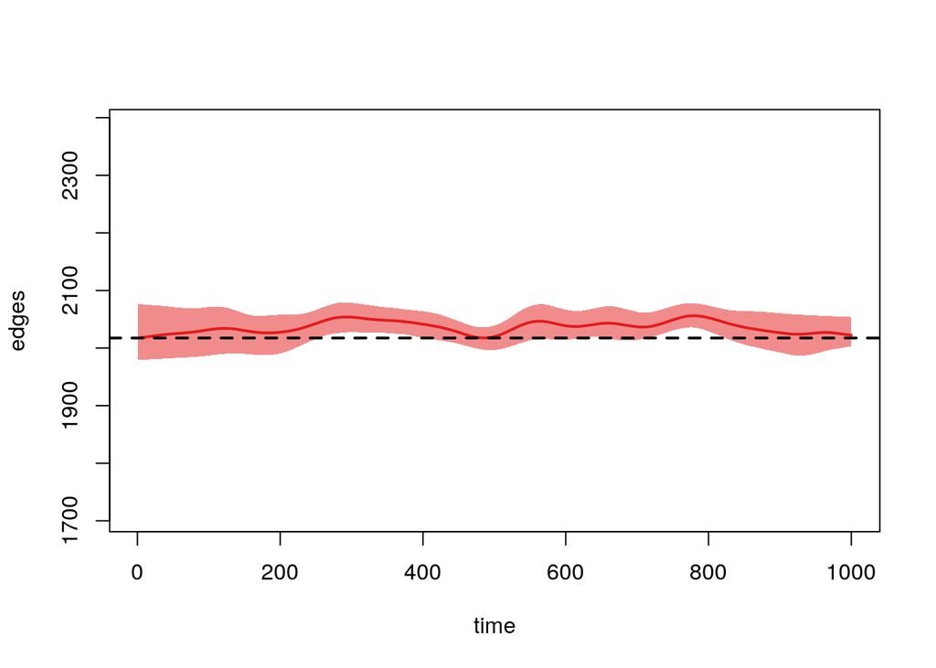

```r
plot(dx_pers2, type="formation")
```

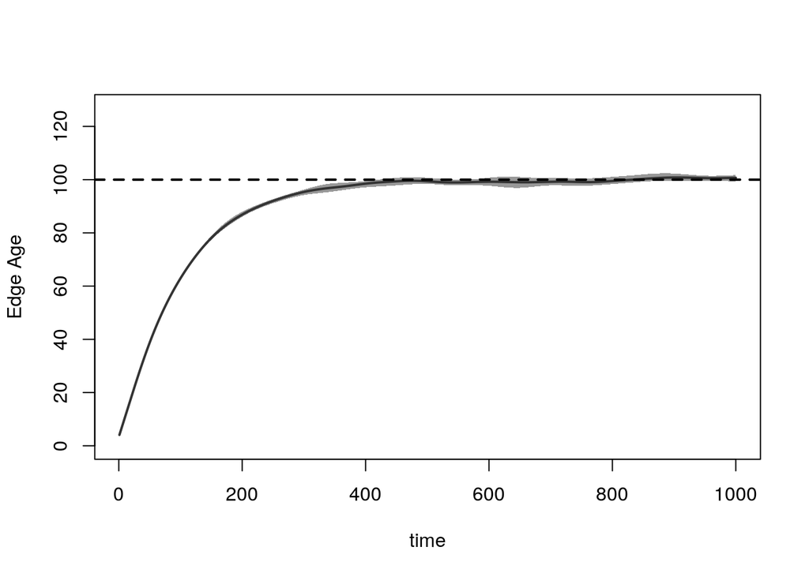

```r
plot(dx_pers2, type="duration")
```

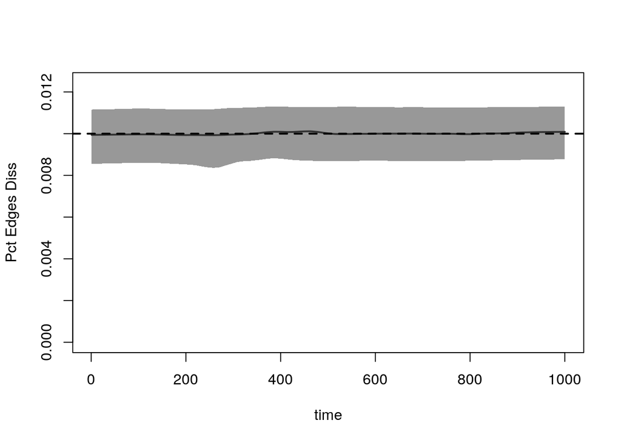

```r
plot(dx_pers2, type="dissolution")
```